# Lab Two: Exploring Image Data

- Yongbin Huang
- Minjie Geng
- Tim Liu

# **1. Business Understanding**

## **1.1 Dataset Information**

The CIFAR-10 dataset consists of **60000** (32x32) **colour** images in 10 classes, with 6000 images per class.

The 10 categories are airplane, automobile, bird, cat, deer, dog, frog, horse, ship, truck.

- **man-made vehicles** (airplanes, automobiles, ships, trucks), which have regular geometric shapes and relatively uniform backgrounds, rely on outline and structural features for recognition.
- **natural animals** (birds, cats, deer, dogs, frogs, horses), which have similar shapes but diverse morphologies and are easily confused with each other, requiring detailed features to distinguish.

Overall, man-made objects are easier to distinguish, while natural animals are more challenging.

## **1.2 Dataset Purpose**

## Objective: Fundamental Research in Image Classification

The Goal of CIFAR-10 Dataset is to provide a balanced, multi-class, labeled collection of small color images for the Image Classification task.

**Birds and airplanes** are a prime example: they both appear in the sky, often feature large blue backgrounds in their images, and both possess a "body + wings" structure, making them easily misclassified in low-resolution data.

**automobiles and trucks** differ primarily in size and shape. Cars are smaller and have a variety of appearances, while trucks are typically larger and feature features like cargo boxes. However, these differences can be blurred in the low-resolution images of CIFAR-10, especially from the front or side, where they can easily be confused.

Similarly, other classes present potential interference. For example, **dogs and cats** are difficult to distinguish due to their similar body shape and fur, while **deer and horses** are often misclassified due to their similarity in size and fur.

These object comparisons highlight the overall trend in the dataset: artificial objects are relatively easy to distinguish, while natural animals are more challenging.

Citation of the dataset

> CIFAR-10 Dataset: https://huggingface.co/datasets/uoft-cs/cifar10

# **2. Data Preparation**

## **2.1 Dataset Load**

```python
import time
import pandas as pd
import numpy as np
from datasets import Dataset
from datasets import load_dataset
import matplotlib.pyplot as plt
import seaborn as sns

# Load dataset
ds = load_dataset("uoft-cs/cifar10")
ds_train=ds["train"]

print(ds_train)
print(ds_train[0])
print(ds_train[0]["img"])
img = ds_train[0]["img"]

# Convert to grayscale and normalize
imgs_gray = [
    np.array(sample["img"].convert("L")) / 255.0
    for sample in ds_train
]
```

```
Dataset({
    features: ['img', 'label'],
    num_rows: 50000
})
{'img': <PIL.PngImagePlugin.PngImageFile image mode=RGB size=32x32 at 0x3CB0A3D0>, 'label': 0}
<PIL.PngImagePlugin.PngImageFile image mode=RGB size=32x32 at 0x3D1D7FD0>
```

## Converting to Grayscale and normalizing the pixel values

performing two crucial data preprocessing steps on the images: converting them to grayscale and normalizing the pixel values. We're taking each color image (which is a 3-channel RGB image) and instantly converting it into a single-channel grayscale image.This dramatically reduces the data dimensionality. The image array shape changes from (32,32,3) to (32,32)Converting to grayscale is often done to reduce computational load for models where color information isn't deemed critical for the classification task. The resulting pixel values (which are integers between 0 and 255) are then converted to a NumPy array (np.array(...)) and divided by 255.0. This scales the pixel values from the range [0,255] to the floating-point range[0.0,1.0].Normalization is a standard practice in machine learning. Scaling input features ensures that all features (pixels) contribute equally to the learning process and helps the model's optimization algorithm (like gradient descent) converge faster and more stably.

## **2.2 Linearize Dataset**

```python
imgs_flat = np.array([
    np.array(sample["img"].convert("L")).flatten()
    for sample in ds_train
])

df_imgs = pd.DataFrame(imgs_flat)
print(df_imgs.shape)
df_imgs.head()

# print(imgs_flat.shape)   # should be (50000, 1024) for CIFAR-10
# print(imgs_flat[0][:20])
```

```
(50000, 1024)
```

|  | 0 | 1 | 2 | 3 | 4 | 5 | 6 | 7 | 8 | 9 | ... | 1014 | 1015 | 1016 | 1017 | 1018 | 1019 | 1020 | 1021 | 1022 | 1023 |
| --- | --- | --- | --- | --- | --- | --- | --- | --- | --- | --- | --- | --- | --- | --- | --- | --- | --- | --- | --- | --- | --- |
| 0 | 178 | 178 | 178 | 178 | 179 | 179 | 179 | 180 | 180 | 180 | ... | 94 | 91 | 91 | 92 | 91 | 90 | 87 | 86 | 87 | 85 |
| 1 | 35 | 28 | 31 | 31 | 34 | 51 | 102 | 148 | 143 | 144 | ... | 13 | 15 | 15 | 19 | 20 | 22 | 25 | 25 | 27 | 26 |
| 2 | 61 | 54 | 47 | 49 | 56 | 57 | 47 | 46 | 48 | 48 | ... | 189 | 187 | 186 | 185 | 184 | 181 | 179 | 177 | 174 | 174 |
| 3 | 56 | 74 | 72 | 76 | 103 | 93 | 51 | 90 | 121 | 117 | ... | 122 | 118 | 117 | 116 | 118 | 118 | 123 | 124 | 119 | 158 |
| 4 | 48 | 92 | 101 | 65 | 58 | 49 | 60 | 89 | 145 | 144 | ... | 201 | 172 | 136 | 107 | 100 | 123 | 133 | 132 | 127 | 104 |

5 rows × 1024 columns

Takes the grayscale image data and performs two more critical operations: Flattening and conversion to a Pandas DataFrame. It transforms the dataset of 50,000 grayscale images (each 32×32 pixels) into a single two-dimensional table (DataFrame), which prepares the data for traditional machine learning processing or data analysis.

## **2.3 Visualize Example**

```
Dataset({
    features: ['img', 'label'],
    num_rows: 10
})
```

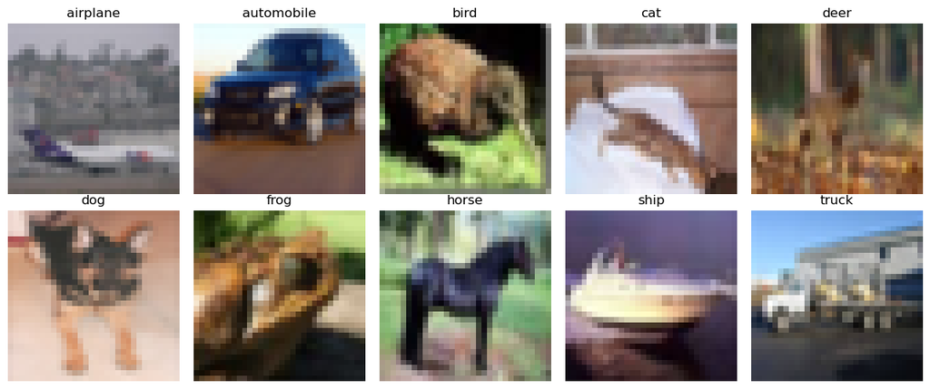

```python
# target_names = {
#     0: "airplane",
#     1: "automobile",
#     2: "bird",
#     3: "cat",
#     4: "deer",
#     5: "dog",
#     6: "frog",
#     7: "horse",
#     8: "ship",
#     9: "truck"
# }
target_names = ["airplane","automobile","bird","cat","deer","dog","frog","horse","ship","truck"]


### Select one image per class
# First create an empty list to store the index of each category
first_indices = []

# Iterate through 10 categories
for label_id in range(10):
    # Find the index of the first sample belonging to this category
    for i, sample in enumerate(ds_train):
        if sample["label"] == label_id:
            first_indices.append(i)
            break
# Use select to generate a new Dataset based on the index
ds_one_per_class = ds_train.select(first_indices)
print(ds_one_per_class)  # 10 items, 1 item per category

# Show 10 grayscale images with labels
fig, axes = plt.subplots(2, 5, figsize=(12, 5))
axes = axes.flatten()

for i, ax in enumerate(axes):
    img = ds_one_per_class[i]["img"]
    label = ds_one_per_class[i]["label"]    # numeric label (0–9)
    ax.imshow(img)
    ax.set_title(target_names[label])   # label lookup by index
    ax.axis("off")

plt.tight_layout()
plt.show()
```

## Selecting One Image Per Class uses Matplotlib to display these 10 images

The first part of the code is designed to find the first instance of each of the 10 categories in the training dataset It loops through all 10 possible label_ids (0 through 9). For each label, it searches through the ds_train set and captures the index (i) of the very first image it finds that matches that label, then immediately breaks the inner loop. These 10 captured indices are stored in the first_indices list. The ds_train.select(first_indices) command uses these indices to create a new, small dataset called ds_one_per_class, which contains exactly 10 images—one representative image for each class.

The second part uses Matplotlib to display these 10 images: Setup: It creates a 2×5 grid of subplots (plt.subplots) to hold the 10 images. It iterates through the 10 selected images. ax.imshow(img) displays the original color image. ax.set_title(target_names[label]) uses the predefined list of names (target_names) to look up and display the human-readable class name (e.g., "airplane," "dog") as the title for each image. ax.axis("off") ensures a clean look by hiding the coordinate axes.

The final result is a 2×5 visual gallery showcasing a distinct example of every object category present in the CIFAR-10 dataset.

# **3. Data Reduction**

## **3.1 Principal Components Analysis (PCA)**

Perform linear dimensionality reduction of the images using principal components analysis. Visualize the explained variance of each component. Analyze how many dimensions are required to adequately represent your image data. Explain your analysis and conclusion.

```python
from collections import defaultdict
# Count how many items are taken from each category
counter = defaultdict(int)

def select_100(example):
    label = example["label"]
    if counter[label] < 100:
        counter[label] += 1
        return True
    return False


# Take 100 of each category
ds_sample = ds_train.filter(select_100)
print("ds_sample:", len(ds_sample))  # 1000 items, 100 items per category
```

```
ds_sample: 1000
```

Conditional filtering operation on the CIFAR-10 training set (ds_train) to create a balanced subset. The goal is to precisely sample 100 examples from each category, resulting in a final, balanced subset of 1,000 images.

The balanced subset ensures that the PCA results are not biased towards overrepresented calsses, giving a fair comparison across all of the 10 categories. By constraining each class to exactly 100 samples, the dimensionality reduction highlights the true potential of the structural patterns for the image, rather than reflecting the class imbalance. This subset will also help reduce computational load, making it more easy to run PCA efficiently whilt keeping variability across the dataset.

```python
from sklearn.decomposition import PCA

# X = [np.array(sample["img"].convert("L")).flatten() for sample in ds_train]
# # X_norm = [np.array(sample["img"].convert("L")).flatten() / 255.0 for sample in ds_train]
# y = np.array(ds_train["label"])
# # print(X[0])

# IF we just use a subset of the data for faster computation

X = [np.array(sample["img"].convert("L")).flatten() for sample in ds_sample]
X_norm = [np.array(sample["img"].convert("L")).flatten() / 255.0 for sample in ds_sample]
y = np.array(ds_sample["label"])
# print(len(X))
# print(len(y))

pca = PCA(n_components=2)
pca.fit(X) # fit data and then transform it
X_pca = pca.transform(X)

print ('defult pca:\n', pca.components_)

pca_norm = PCA(n_components=2)
pca_norm.fit(X_norm) # fit data and then transform it
X_norm_pca = pca_norm.transform(X_norm)

print ('Norm pca:\n', pca_norm.components_)
```

```
defult pca:
 [[ 0.04949374  0.04951814  0.04909246 ...  0.02852344  0.02940226
   0.02944664]
 [-0.02922055 -0.02878379 -0.02943686 ...  0.04397016  0.04196455
   0.0401832 ]]
Norm pca:
 [[ 0.04949374  0.04951814  0.04909246 ...  0.02852344  0.02940226
   0.02944664]
 [-0.02922055 -0.02878379 -0.02943686 ...  0.04397016  0.04196455
   0.0401832 ]]
```

When data is normalized, PCA can treat every feature (pixel) more equally, leading to a more representative and meaningful low-dimensional representation for the model.

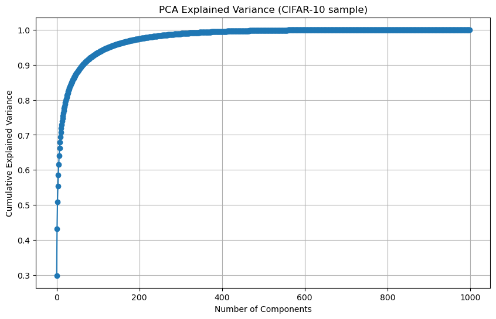

```
~90% variance explained with 65 components
```

```python
max_comp = min(np.array(ds_sample).shape)  # = 1000 here
pca_full = PCA(n_components=max_comp)
pca_full.fit(np.array(X_norm))

explained_var = pca_full.explained_variance_ratio_
cum_var_exp = np.cumsum(explained_var)

plt.figure(figsize=(10,6))
plt.plot(cum_var_exp, marker="o")
plt.xlabel("Number of Components")
plt.ylabel("Cumulative Explained Variance")
plt.title("PCA Explained Variance (CIFAR-10 sample)")
plt.grid(True)
plt.show()

n90 = np.argmax(cum_var_exp >= 0.90) + 1
print(f"~90% variance explained with {n90} components")
```

A complete Principal Component Analysis (PCA) and uses the results to answer a critical question: How many principal components are required to retain 90% of the data's information? This means that while the original images have 1,024 features (pixels), you only need to select the first 65 principal components to retain approximately 90% of the useful information in the original data. Compared to the original 1024-dimensional feature space, reducing the data to just 65 dimensions is a huge simplification (a dimensionality reduction of over 93%). This can dramatically decrease the training time and memory requirements for subsequent machine learning models (like SVMs or neural networks), all while losing only 10% of the information.

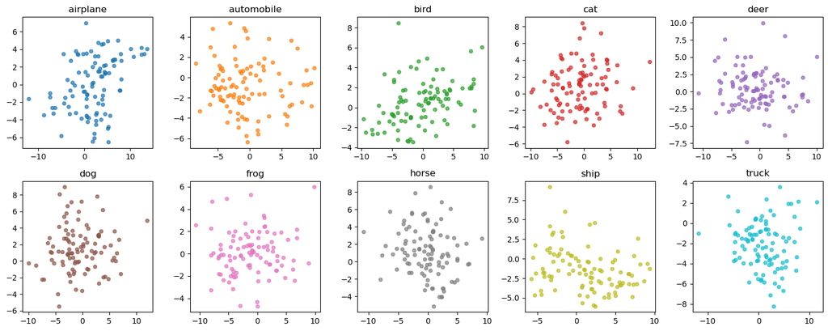

```python
# 5. Define and train PCA model
pca_norm = PCA(n_components=2)
pca_norm.fit(X_norm)
X_norm_pca = pca_norm.transform(X_norm)

cmap = sns.set_theme(style="darkgrid")

# Function to format weights
def get_feature_names_from_weights(weights, names):
    tmp_array = []
    for comp in weights:
        tmp_string = ''
        for fidx,f in enumerate(names):
            if fidx>0 and comp[fidx]>=0:
                tmp_string+='+'
            tmp_string += '%.2f*%s ' % (comp[fidx],f[:-5])
        tmp_array.append(tmp_string)
    return tmp_array

plt.style.use('default')

# Now let's get to the Data Analytics
pca_weight_strings = get_feature_names_from_weights(pca_norm.components_, target_names)

df_pca = pd.DataFrame(X_norm_pca, columns=[pca_weight_strings])

fig, axes = plt.subplots(2, 5, figsize=(15, 6))
axes = axes.flatten()

# Plotting the PCA results
for i in range(10):
    ax = axes[i]
    mask = (y == i)
    ax.scatter(X_norm_pca[mask, 0], X_norm_pca[mask, 1], c=f"C{i}", s=20, alpha=0.7)
    ax.set_title(target_names[i])

plt.tight_layout()
plt.show()
```

Visually evaluate the effectiveness of PCA:

By observing these 10 scatter plots, you can determine if the images of different classes can be clearly separated in the reduced 2-dimensional space. While some classes show partial clustering, there is still significant overlap between categories such as cats and dogs, which are fairly similar. If the points for different classes overlap heavily in the plots, it indicates that the variance captured by PC1 and PC2 is insufficient for good classification.

```
PCA running time: 2.9925 Sec
```

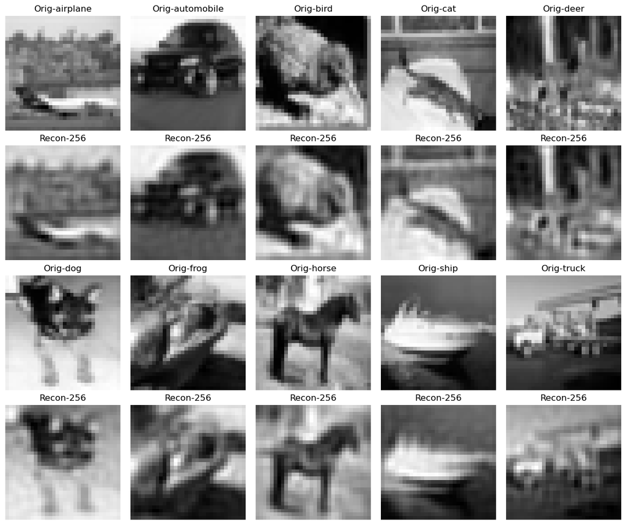

```python
# Reconstruct with fewer components
n_components = 256
start_time = time.time()

pca_recon = PCA(n_components=n_components)
X_reduced = pca_recon.fit_transform(imgs_flat)
X_reconstructed = pca_recon.inverse_transform(X_reduced)

end_time = time.time()
print(f"PCA running time: {end_time - start_time:.4f} Sec")

# Show first 5 examples with side-by-side comparison
fig, axes = plt.subplots(4, 5, figsize=(12, 10))  # 4 rows, 5 columns
for i in range(5):
    # Original (first column of the pair)
    axes[0,i].imshow(ds_one_per_class[i]["img"].convert("L"), cmap="gray")
    axes[0,i].set_title("Orig-"+target_names[i])
    axes[0,i].axis("off")

    # Reconstructed (second column of the pair)
    axes[1,i].imshow(X_reconstructed[first_indices[i]].reshape(32,32), cmap="gray")
    axes[1,i].set_title(f"Recon-{n_components}")
    axes[1,i].axis("off")

    # Original again (third column of the pair)
    axes[2,i].imshow(ds_one_per_class[i+5]["img"].convert("L"), cmap="gray")
    axes[2,i].set_title("Orig-"+target_names[i+5])
    axes[2,i].axis("off")

    # Reconstructed again (fourth column of the pair)
    axes[3,i].imshow(X_reconstructed[first_indices[i+5]].reshape(32,32), cmap="gray")
    axes[3,i].set_title(f"Recon-{n_components}")
    axes[3,i].axis("off")

plt.tight_layout()
plt.show()
```

The dimensionality limit for PCA is min(n_samples, n_features). This is related to the number of samples and features. So we just choose 256 components.

It took about 2.9s to calculate the PCA for this data set.

Experiments with PCA show that, on CIFAR-10 images, only a small number of principal components (e.g., 256) can preserve the general structure of the categories, indicating a high degree of redundancy in image data. However, to maintain good performance in classification or recognition tasks, more dimensions are required to supplement and distinguish details. Therefore, PCA can significantly reduce dimensionality while still effectively representing data features, making it an effective image dimensionality reduction method.

## **3.2 Randomized Principal Components Analysis (RPCA)**

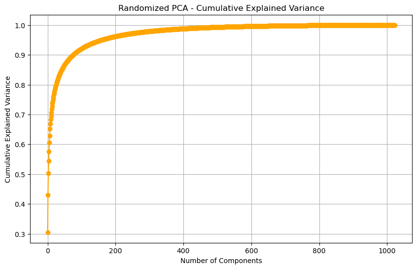

```
Number of components for ~90% variance (Randomized PCA): 77
```

```python
# Randomized PCA (faster on large datasets)
rpca = PCA(svd_solver="randomized", random_state=42)
X_rpca = rpca.fit_transform(imgs_flat)
explained_variance_rpca = rpca.explained_variance_ratio_
cumulative_variance_rpca = np.cumsum(explained_variance_rpca)

plt.figure(figsize=(10, 6))
plt.plot(cumulative_variance_rpca, marker="o", color="orange")
plt.xlabel("Number of Components")
plt.ylabel("Cumulative Explained Variance")
plt.title("Randomized PCA - Cumulative Explained Variance")
plt.grid(True)
plt.show()

n_components_90_rpca = np.argmax(cumulative_variance_rpca >= 0.90) + 1
print(f"Number of components for ~90% variance (Randomized PCA): {n_components_90_rpca}")
```

This number represents your dimensionality reduction target. It tells you the maximum number of dimensions you need to compress the original 1024-dimensional feature space down to, in order to efficiently retain 90% of the important data characteristics when using the randomized method. The original 1024-dimensional feature space can be reduced to between 65 and 77 dimensions while still retaining 90% of the data's information. This translates directly to a significant boost in computational efficiency. Standard PCA (on the smaller sample): Requires only 65 components. Randomized PCA (on the full or larger dataset): Requires 77 components. This slight discrepancy (77 vs. 65) is normal. It is likely due to the approximating nature of the randomized algorithm, or because the full dataset contains more noise and finer detail, requiring slightly more principal components to capture 90% of the total variance. Both curves show extremely high information concentration. The curve rises sharply and then flattens out within the first 100 to 200 components, indicating that more than 90% of the variance is captured within this initial, small set of dimensions.

```
RPCA running time: 2.6648 Sec
```

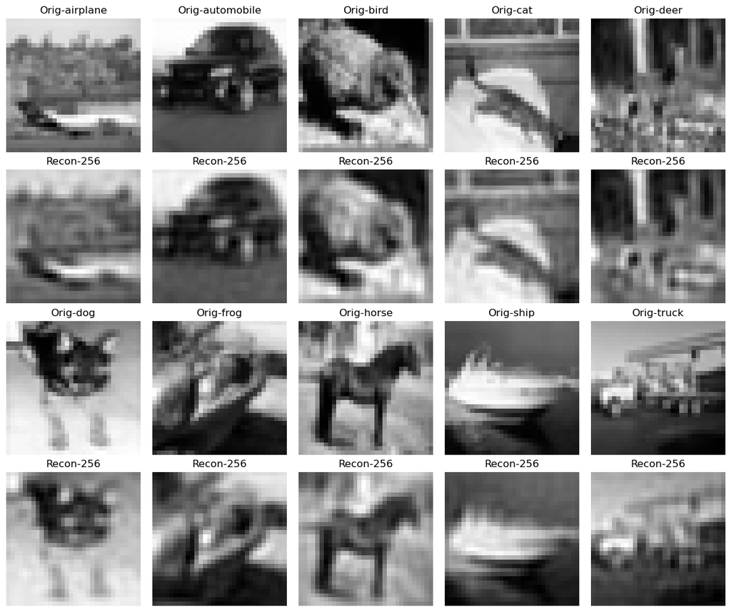

```python
start_time = time.time()

# Reconstruct with fewer components
rpca_recon = PCA(n_components=n_components, svd_solver="randomized", random_state=42)
X_rpca_reduced = rpca_recon.fit_transform(imgs_flat)
X_rpca_reconstructed = rpca_recon.inverse_transform(X_rpca_reduced)

end_time = time.time()
print(f"RPCA running time: {end_time - start_time:.4f} Sec")

# Show first 5 examples with side-by-side comparison
fig, axes = plt.subplots(4, 5, figsize=(12, 10))  # 4 rows, 5 columns
for i in range(5):
    # Original (first column of the pair)
    axes[0,i].imshow(ds_one_per_class[i]["img"].convert("L"), cmap="gray")
    axes[0,i].set_title("Orig-"+target_names[i])
    axes[0,i].axis("off")

    # Reconstructed (second column of the pair)
    axes[1,i].imshow(X_rpca_reconstructed[first_indices[i]].reshape(32,32), cmap="gray")
    axes[1,i].set_title(f"Recon-{n_components}")
    axes[1,i].axis("off")

    # Original again (third column of the pair)
    axes[2,i].imshow(ds_one_per_class[i+5]["img"].convert("L"), cmap="gray")
    axes[2,i].set_title("Orig-"+target_names[i+5])
    axes[2,i].axis("off")

    # Reconstructed again (fourth column of the pair)
    axes[3,i].imshow(X_rpca_reconstructed[first_indices[i+5]].reshape(32,32), cmap="gray")
    axes[3,i].set_title(f"Recon-{n_components}")
    axes[3,i].axis("off")

plt.tight_layout()
plt.show()
```

It took about 2.6s to calculate the PCA for this dataset.

We performed Randomized PCA (Randomized Principal Component Analysis) on the dataset to reduce data dimensionality and extract key features. We selected the number of principal components retained by setting the n_components parameter to 256, accelerated the singular value decomposition computation using svd_solver="randomized" , and ensured reproducibility by specifying random_state=42 . The analysis results show that the data retains key information in the low-dimensional space.

## **3.3 Comparing PCA vs RPCA**

```
13.170188978922198 -13.921954768907426
```

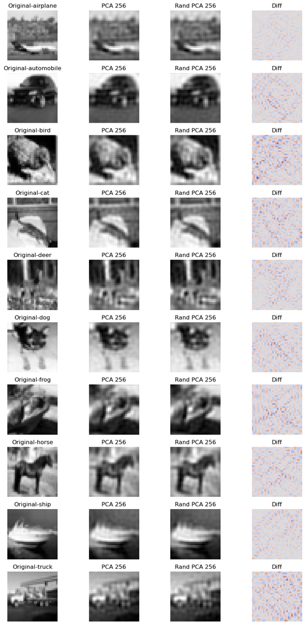

```python
# Show first 5 original + PCA recon + Randomized PCA recon
fig, axes = plt.subplots(10, 4, figsize=(10, 18))
for i in range(10):
    axes[i,0].imshow(ds_one_per_class[i]["img"].convert("L"), cmap="gray")
    axes[i,0].set_title("Original-"+target_names[i])
    axes[i,0].axis("off")

# Standard PCA
    axes[i,1].imshow(X_reconstructed[first_indices[i]].reshape(32,32), cmap="gray")
    axes[i,1].set_title(f"PCA {n_components}")
    axes[i,1].axis("off")

# Randomized PCA
    axes[i,2].imshow(X_rpca_reconstructed[first_indices[i]].reshape(32,32), cmap="gray")
    axes[i,2].set_title(f"Rand PCA {n_components}")
    axes[i,2].axis("off")

    axes[i,3].imshow((X_reconstructed[first_indices[i]]-X_rpca_reconstructed[first_indices[i]]).reshape(32,32), cmap="coolwarm", vmin=-20, vmax=20)
    axes[i,3].set_title(f"Diff")
    axes[i,3].axis("off")
print(max(X_reconstructed[first_indices[i]]-X_rpca_reconstructed[first_indices[i]]),min(X_reconstructed[i]-X_rpca_reconstructed[i]))
plt.tight_layout()
plt.show()
```

Original (Column 1): The original grayscale image.

PCA 256 (Column 2): The image reconstructed by Standard PCA.

Rand PCA 256 (Column 3): The image reconstructed by Randomized PCA.

visually assess the accuracy of Randomized PCA as an approximation method:

If Column 4 shows significant bright areas, it reveals a noticeable difference between the two reconstructions, highlighting the approximation error introduced by the randomized algorithm at this low dimensionality.

This comparison helps the user decide if the speed benefit of Randomized PCA on large datasets is a worthwhile trade-off for the potential small loss of precision.

Visualizing the projection results reveals some differences between PCA and RPCA. For images with a scale of 0-255, the difference, within the range of 13, is actually quite small. Furthermore, the actual performance differences are not significant.

```python
from sklearn.metrics import mean_squared_error

# Choose some number of components (say 50)

# Standard PCA
X_pca50 = pca_recon.transform(imgs_flat)
X_pca_reconstructed = pca_recon.inverse_transform(X_pca50)

# Randomized PCA
X_rpca50 = rpca_recon.transform(imgs_flat)
X_rpca_reconstructed = rpca_recon.inverse_transform(X_rpca50)

# Compare reconstruction error
err_pca = mean_squared_error(imgs_flat, X_pca_reconstructed)
err_rpca = mean_squared_error(imgs_flat, X_rpca_reconstructed)

print(f"Reconstruction error with PCA (50 comps): {err_pca:.4f}")
print(f"Reconstruction error with Randomized PCA (50 comps): {err_rpca:.4f}")
```

```
Reconstruction error with PCA (50 comps): 100.1665
Reconstruction error with Randomized PCA (50 comps): 100.1517
```

The results show that the reconstruction error for standard PCA is **100.1665**, while that for randomized PCA is **100.1517**.

These two errors are very close, indicating that randomized PCA is nearly identical to traditional PCA in preserving the key information in the data.

RPCA is slightly faster than PCA in processing the same data.

Overall, RPCA is effective for data dimensionality reduction and pattern discovery. This method exhibits high computational efficiency and low memory consumption when processing large-scale data, making it suitable for rapid exploratory analysis with high feature dimensionality.

# **4. Feature extraction**

## **4.1 Gabor filters** for Texture analysis

Perform feature extraction and visualization on 10 representative images (ds_one_per_class, one from each category) using Gabor Filters.

Gabor filters are commonly used in computer vision to extract texture and edge information from images, as they are particularly sensitive to features oriented at specific directions and frequencies.

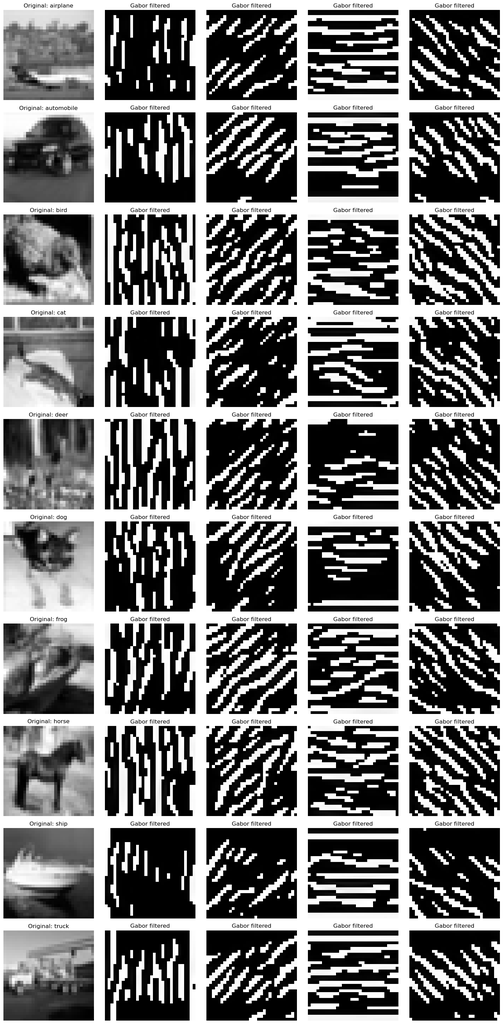

```python
import matplotlib.pyplot as plt
from skimage.filters import gabor_kernel
from scipy import ndimage as ndi
import numpy as np

h, w = 32, 32

kernels=[]

for theta_idx in range(4):
    theta = theta_idx / 4. * np.pi
    kernel = np.real(gabor_kernel(0.25,theta=theta))  # frequency 默认 0.25
    kernels.append(kernel)

# print(kernels)
# print(len(kernels))
num_images = len(ds_one_per_class)
num_kernels = len(kernels)

fig, axes = plt.subplots(num_images, len(kernels)+1, figsize=(15, num_images*3))

for i in range(num_images):
    sample = ds_one_per_class[i]
    img_gray = np.array(sample["img"].convert("L"))
    label = sample["label"]

    axes[i, 0].imshow(img_gray, cmap="gray")
    axes[i, 0].set_title(f"Original: {target_names[label]}")
    axes[i, 0].axis("off")

    for kernel_idx in range(4):
        filtered = ndi.convolve(img_gray, kernels[kernel_idx], mode='wrap')
        axes[i, kernel_idx+1].imshow(filtered, cmap="gray")
        axes[i, kernel_idx+1].set_title(f"Gabor filtered")
        axes[i, kernel_idx+1].axis("off")

plt.tight_layout()
plt.show()
```

This table summarizes the response patterns of the Gabor filters across the four directions: 0∘(Vertical), 45∘(Oblique), 90∘(Horizontal), and 135∘(Oblique).

| Category | Primary Feature Type | Key Response Direction / Dominant Pattern | Detailed Explanation |
| --- | --- | --- | --- |
| **Airplane, Ship** | Horizontal Dominant | Horizontal (90°) response is extremely strong; Vertical (0°) and 45° are strong. | Man-made/Mechanical. Feature concentrated on clear, consistent **horizontal primary contours** (fuselage, waterline, horizon). |
| **Automobile, Truck** | Vertical / Horizontal | Vertical (0°) and Horizontal (90°) responses are both strong. | Man-made/Mechanical. Feature distribution is **balanced**, capturing both vertical structures (doors, tire sides) and horizontal structures (roof, chassis). |
| **Deer, Dog, Horse** | Oblique / Complex | **Oblique (45°, 135°)** response is strong; Vertical (0°) is present. | Biological/Animal. Contours are complex and non-orthogonal. Oblique filters capture body shapes and limbs more effectively. (Deer's vertical response often comes from **background elements**). |
| **Bird, Cat** | Oblique / Complex | **Oblique (45°, 135°)** filter response is strong. | Biological/Animal. Contours are irregular; **oblique features dominate**, capturing body outlines and complex fur/feather textures. |
| **Frog** | Uniformly Dispersed | **All directions** produce a large amount of scattered, random white specks. | Biological/Environment Mix. Lacks a single dominant, uniform edge direction due to **complex background textures** (grass/leaves), leading to a less informative, dispersed response. |

| Object Type | Dominant Response Directions | Feature Characterization |
| --- | --- | --- |
| **Mechanical/Man-Made Objects** | Horizontal (90°) and Vertical (0°) | Features are **concentrated in the primary orthogonal directions**, resulting in clearer, structural outlines. |
| **Biological/Animal Objects** | Oblique (45° and 135°) | **Contours are more complex**, and features are dominated by oblique edges, making them more challenging to classify based solely on horizontal/vertical features. |

## **4.1 Sobel filters** for Edge detection

Perform edge detection and visualization on 10 representative images using the Sobel Filter.

The Sobel filter is a classic image processing operator used to emphasize areas of significant intensity change in an image—that is, the edges. This code is designed to visually demonstrate how the Sobel filter decomposes an image into its fundamental horizontal and vertical edge components. By observing the Sobel results, you can determine if the object's main contours and structure are concentrated in the horizontal or vertical directions. This aligns with the previous Gabor filter analysis theme: quantifying the directional characteristics of the image.

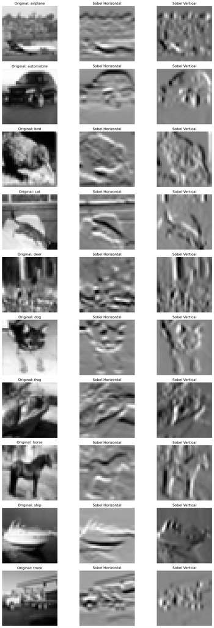

```python
import matplotlib.pyplot as plt
from skimage import filters
import numpy as np

num_images = len(ds_one_per_class)

fig, axes = plt.subplots(num_images, 3, figsize=(12, num_images*3))

for i in range(num_images):
    sample = ds_one_per_class[i]
    img_gray = np.array(sample["img"].convert("L"))
    label = sample["label"]

    axes[i, 0].imshow(img_gray, cmap="gray")
    axes[i, 0].set_title(f"Original: {target_names[label]}")
    axes[i, 0].axis("off")

    sobel_h = filters.sobel_h(img_gray)
    axes[i, 1].imshow(sobel_h, cmap="gray")
    axes[i, 1].set_title("Sobel Horizontal")
    axes[i, 1].axis("off")

    sobel_v = filters.sobel_v(img_gray)
    axes[i, 2].imshow(sobel_v, cmap="gray")
    axes[i, 2].set_title("Sobel Vertical")
    axes[i, 2].axis("off")

plt.tight_layout()
plt.show()
```

Feature Pattern: The Sobel filter successfully decomposes the images into basic orthogonal edge components. This reveals that the edges of mechanical objects (like the airplane and truck) are primarily concentrated in the horizontal and vertical directions, whereas biological objects exhibit a more complex pattern.

## **4.3 DAISY** for Dense feature extraction

The purpose of this code is to perform local feature extraction and visualization on an image using DAISY Descriptors.

DAISY is a well-known feature descriptor based on the concept of Histogram of Oriented Gradients (HOG), which is used to capture local texture and shape information around key points in an image.

```
DAISY descriptors shape: (3, 3, 40)
DAISY descriptors shape: (3, 3, 40)
DAISY descriptors shape: (3, 3, 40)
DAISY descriptors shape: (3, 3, 40)
DAISY descriptors shape: (3, 3, 40)
DAISY descriptors shape: (3, 3, 40)
DAISY descriptors shape: (3, 3, 40)
DAISY descriptors shape: (3, 3, 40)
DAISY descriptors shape: (3, 3, 40)
DAISY descriptors shape: (3, 3, 40)
```

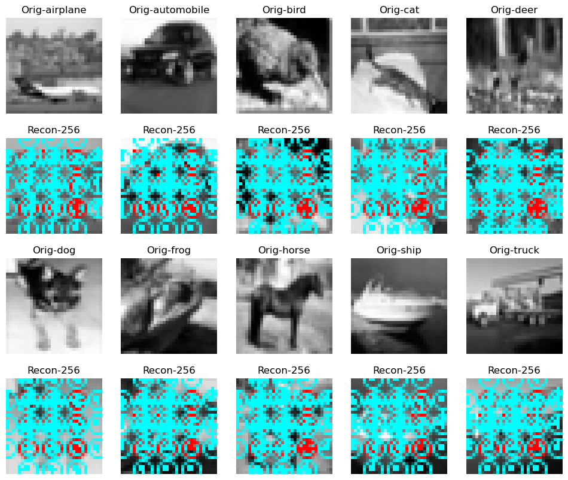

```python
from skimage.feature import daisy
from skimage.color import rgb2gray
# Convert to grayscale (DAISY works on grayscale)

fig, axes = plt.subplots(4, 5, figsize=(12, 10))  # 4 rows, 5 columns

def img2daisy(img):
    gray = rgb2gray(np.array(img))

    # Extract DAISY features
    descs, img_desc = daisy(gray,
                               step=8,
                               radius=7,
                               rings=1,
                               histograms=4,
                               orientations=8,
                               visualize=True)
    print("DAISY descriptors shape:", descs.shape)
    return descs, img_desc

for i in range(5):
    img = ds_one_per_class[i]["img"]
    descs, img_desc = img2daisy(img)


    img = ds_one_per_class[i+5]["img"]
    descs1, img_desc1 = img2daisy(img)

    # Original
    axes[0,i].imshow(ds_one_per_class[i]["img"].convert("L"), cmap="gray")
    axes[0,i].set_title("Orig-"+target_names[i])
    axes[0,i].axis("off")

    # Show the visualization of DAISY keypoints
    axes[1,i].imshow(img_desc, cmap="gray")
    axes[1,i].set_title(f"Recon-{n_components}")
    axes[1,i].axis("off")

    # Original
    axes[2,i].imshow(ds_one_per_class[i+5]["img"].convert("L"), cmap="gray")
    axes[2,i].set_title("Orig-"+target_names[i+5])
    axes[2,i].axis("off")

    # Show the visualization of DAISY keypoints
    axes[3,i].imshow(img_desc1, cmap="gray")
    axes[3,i].set_title(f"Recon-{n_components}")
    axes[3,i].axis("off")
```

# DAISY Feature Visualization Analysis

Each small square: Represents one or a group of numerical values within the feature vector. Color and Brightness: Typically represent the strength, orientation, or type of the feature. In image processing visualization: Different colors (hues) may represent different Gradient Orientations. The DAISY descriptor is essentially a Histogram of Gradient Orientations. The depth or brightness of the color may represent the Magnitude (or strength) of the gradient in that direction.

## **5. Conclusion**

The core objective of this study was to address the central challenge of multi-class image classification on the low-resolution CIFAR-10 dataset, specifically focusing on to identify the most promising classification path, this research systematically evaluated dimensionality reduction (PCA and Randomized PCA) and feature extraction (e.g., Gabor or DAISY features) techniques, with the goal of determining a robust image representation method capable of effectively distinguishing categories like man-made objects from natural animals.

## **Reference**

Learning multiple layers of features from tiny images

> Alex Krizhevsky, "Learning multiple layers of features from tiny images",Hugging Face, 2009, https://huggingface.co/datasets/uoft-cs/cifar10